# SMEA 586: Problem Set 1

Brian McGreal

April 17, 2024

We will explore questions related to US citizen’s opinions on climate change using data from the [Yale Program on Climate Change Communication](https://climatecommunication.yale.edu/visualizations-data/ycom-us/).

Specifically, we will create maps from the 2023 county-level estimates of: (1) Estimated percentage who think global warming will harm people in developing countries a moderate amount/a great deal (`devharm`); and (2) Estimated percentage who think global warming will harm people in the US a moderate amount/a great deal (`harmus`), along with US Census Bureau’s county boundaries that can be downloaded using the [tigris package](https://github.com/walkerke/tigris).

The Yale data are provided on our course website and should be saved to your `data` subdirectory.

1. Start by reading in Yale data from 2023, which comes as a .xlsx file and are stored in the tab `YCOM_2023` (I’ve done this part for you). Then select the county-level observations. Call this object `clim_dat`.

```r
clim_dat <- read_excel(here("data", "YCOM7_publicdata.xlsx"), sheet = "YCOM_2023")
class(clim_dat)
```

```
## [1] "tbl_df"     "tbl"        "data.frame"
```

```r
clim_dat <- clim_dat %>% filter(geotype == "county")
```

2. Now use the [`tigris` package](https://github.com/walkerke/tigris) to load in county borders from 2023, naming this spatial dataset `us_counties`. Note that the default is to download high-resolution data, best for visualizing a small number of counties, but not necessary for our purposes.

```r
us_counties <- counties(state = NULL, cb = FALSE, resolution = "500k", year = 2023, progress_bar = FALSE)
```

3. Next load the dataset `us_states.csv` (I did this part for you), selecting the variables `STATEFP` and `NAME`, and join these data to `us_counties` by FIPs code.

```r
us_states <- read_csv(here("data", "us_states.csv"))
class(us_states)
```

```
## [1] "spec_tbl_df" "tbl_df"      "tbl"         "data.frame"
```

```r
us_counties <- full_join(us_counties, us_states, by = "STATEFP")
class(us_counties)
```

```
## [1] "sf"         "data.frame"
```

4. Note that `clim_dat` has a variable named `geoname` that can, in theory, be matched with the variable `NAMELSAD` in `us_counties`, but the formatting isn’t right. Here, you will use the function [`separate_wider_delim()`](https://tidyr.tidyverse.org/reference/separate_wider_delim.html) to reformat `geoname`. Note that you want to include any spaces in your definition of the delimiter (I discovered this the hard way).

```r
clim_dat <- separate_wider_delim(
   clim_dat,
   geoname,
   ", ",
   names = c("County", "State"),
   too_few = "debug",
   cols_remove = TRUE)
```

```r
class(clim_dat)
```

```
## [1] "tbl_df"     "tbl"        "data.frame"
```

```r
  # clim_dat is not a spatial dataframe, nor was it to begin with
  # is there a way to convert it?
class(us_counties)
```

```
## [1] "sf"         "data.frame"
```

6. Join the `clim_dat` and `us_counties` dataset to generate a spatial (sf) dataframe called `clim_counties`.

**Question: which counties were you unable to match to the Yale data?**

```r
names(clim_dat)
```

```
##  [1] "geotype"                   "geoid"
##  [3] "County"                    "State"
##  [5] "geoname"                   "geoname_ok"
##  [7] "geoname_pieces"            "geoname_remainder"
##  [9] "count"                     "discuss"
## [11] "discussOppose"             "reducetax"
## [13] "reducetaxOppose"           "prioritycleanenergy"
## [15] "prioritycleanenergyOppose" "localofficials"
## [17] "localofficialsOppose"      "governor"
## [19] "governorOppose"            "congress"
## [21] "congressOppose"            "president"
## [23] "presidentOppose"           "corporations"
## [25] "corporationsOppose"        "citizens"
## [27] "citizensOppose"            "regulate"
## [29] "regulateOppose"            "drilloffshore"
```

[output cut: 21 more lines]

```r
names(us_counties)
```

```
##  [1] "STATEFP"    "COUNTYFP"   "COUNTYNS"   "GEOID.x"    "GEOIDFQ.x"
##  [6] "NAME.x"     "NAMELSAD"   "LSAD.x"     "CLASSFP"    "MTFCC.x"
## [11] "CSAFP"      "CBSAFP"     "METDIVFP"   "FUNCSTAT.x" "ALAND.x"
## [16] "AWATER.x"   "INTPTLAT.x" "INTPTLON.x" "REGION"     "DIVISION"
## [21] "STATENS"    "GEOID.y"    "GEOIDFQ.y"  "STUSPS"     "NAME.y"
## [26] "LSAD.y"     "MTFCC.y"    "FUNCSTAT.y" "ALAND.y"    "AWATER.y"
## [31] "INTPTLAT.y" "INTPTLON.y" "geometry"
```

```r
names(us_counties)[names(us_counties) == "NAMELSAD"] <- "County"
names(us_counties)[names(us_counties) == "NAME.y"] <- "State"
names(us_counties)
```

```
##  [1] "STATEFP"    "COUNTYFP"   "COUNTYNS"   "GEOID.x"    "GEOIDFQ.x"
##  [6] "NAME.x"     "County"     "LSAD.x"     "CLASSFP"    "MTFCC.x"
## [11] "CSAFP"      "CBSAFP"     "METDIVFP"   "FUNCSTAT.x" "ALAND.x"
## [16] "AWATER.x"   "INTPTLAT.x" "INTPTLON.x" "REGION"     "DIVISION"
## [21] "STATENS"    "GEOID.y"    "GEOIDFQ.y"  "STUSPS"     "State"
## [26] "LSAD.y"     "MTFCC.y"    "FUNCSTAT.y" "ALAND.y"    "AWATER.y"
## [31] "INTPTLAT.y" "INTPTLON.y" "geometry"
```

```r
clim_counties <- full_join(us_counties, clim_dat, by = c("County", "State"))
class(clim_counties)
```

```
## [1] "sf"         "data.frame"
```

```r
clim_counties <- subset(clim_counties, select = c("County", "State", "geoname", "count", "harmus", "devharm"))
class(clim_counties)
```

```
## [1] "sf"         "data.frame"
```

```r
names(clim_counties)
```

```
## [1] "County"   "State"    "geoname"  "count"    "harmus"   "devharm"  "geometry"
```

7. Map the estimated percentage in a county that believe climate change will harm people in developing countries for US counties in the **contiguous US** using a [colorblind-friendly color palette](https://knightlab.northwestern.edu/2016/07/18/three-tools-to-help-you-make-colorblind-friendly-graphics/) diverging color scale centered at the mean for the country. Define the fill for counties without a `devharm` estimate as “grey80” (lighter than the default). Save it as a pdf to your output folder named “ps1_fig1_lastname.pdf” (where you replace lastname with your actual last name). Note that the lat/long boundaries of the contiguous US are provided on this [Quora blog](https://www.quora.com/What-is-the-longitude-and-latitude-of-a-bounding-box-around-the-continental-United-States). **Question: interpret this map.**

```r
st_bbox(clim_counties)
```

```
##       xmin       ymin       xmax       ymax
## -179.23109  -14.60181  179.85968   71.43979
```

```r
clim_crop <- st_crop(
  clim_counties,
  xmin = -125, ymin = 20,
  xmax = -66.94, ymax = 49.39
)
st_bbox(clim_crop)
```

```
##       xmin       ymin       xmax       ymax
## -124.84897   24.39631  -66.94000   49.38448
```

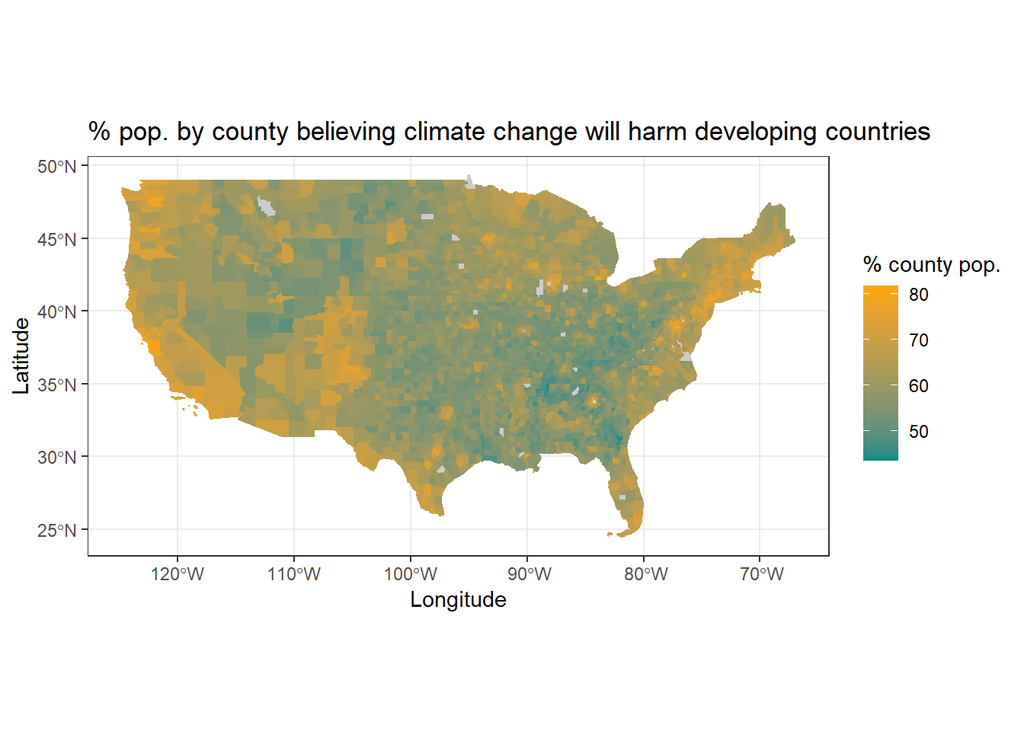

```r
q7 <- ggplot() +
  geom_sf(data = clim_crop, color = "transparent",
          aes(fill = devharm)) +
  scale_fill_continuous(
    "% county pop.",
    low = "cyan4", high = "orange", na.value="grey80") +
  labs(
    x = "Longitude",
    y = "Latitude",
    title = "% pop. by county believing climate change will harm developing countries"
  ) +
  theme_bw()
q7
```

```r
ggsave(
  filename = here("output", "ps1_fig1_mcgreal.pdf"),
  plot = q7
)
```

8. Now create a map showing the divergence between beliefs that climate change will harm people in developing countries and beliefs that climate change will harm people in the US. Use a colorblind-friendly diverging color scale centered around zero. Again, define the fill for counties without data metric as “grey80” (lighter than the default). **Question: interpret this map.**

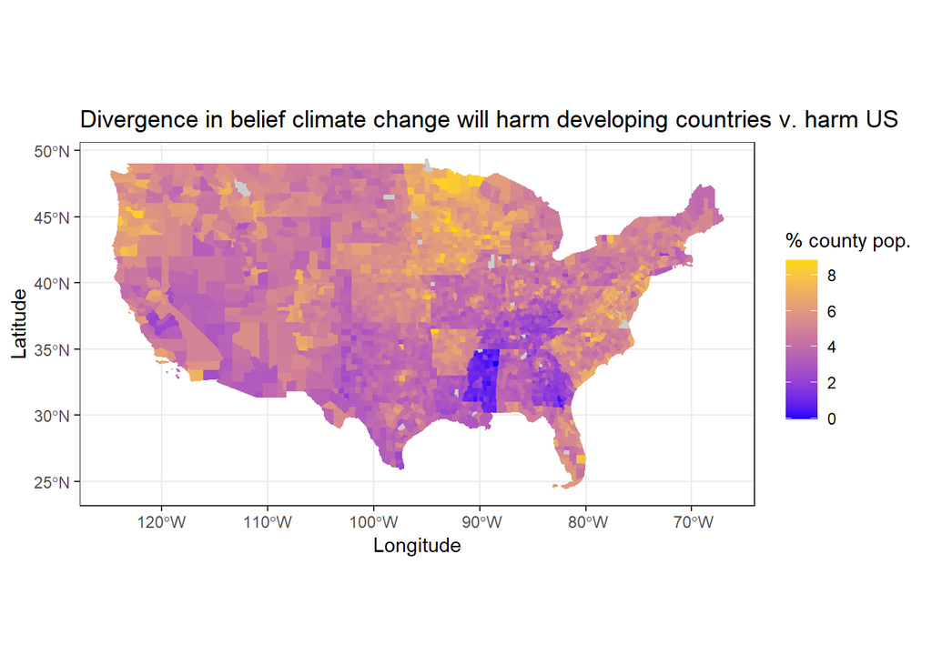

```r
clim_crop$harmdiff <- clim_crop$devharm - clim_crop$harmus

ggplot() +
  geom_sf(data = clim_crop, color = "transparent",
          aes(fill = harmdiff)) +
  scale_fill_continuous(
    "% county pop.",
    low = "blue", high = "gold", na.value="grey80") +
  labs(
    x = "Longitude",
    y = "Latitude",
    title = "Divergence in belief climate change will harm developing countries v. harm US"
  ) +
  theme_bw()
```

9. Aggregate the county-level data to the state level and calculate the fraction of people in the state that believe climate change will harm people in developing countries. Plot these data and name the figure “ps1_fig3_lastname.pdf” (where you replace lastname with your actual last name).

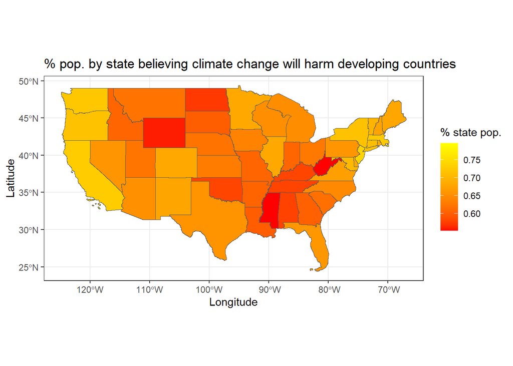

```r
clim_crop$devharm_count = (clim_crop$devharm/100) * clim_crop$count

clim_cropSTATE <- clim_crop %>%
  group_by(State) %>%
  summarize(
    count = sum(count, na.rm = TRUE),
    devharm_count = sum(devharm_count, na.rm = TRUE)
  )

clim_cropSTATE$devharm <- clim_cropSTATE$devharm_count / clim_cropSTATE$count

q9 <- ggplot() +
  geom_sf(data = clim_cropSTATE,
          aes(fill = devharm)) +
  scale_fill_continuous(
    "% state pop.",
    low = "red", high = "yellow", na.value="grey80") +
  labs(
    x = "Longitude",
    y = "Latitude",
    title = "% pop. by state believing climate change will harm developing countries"
  ) +
  theme_bw()
q9
```

```r
ggsave(
  filename = here("output", "ps1_fig3_mcgreal.pdf"),
  plot = q9
)
```